# Table of Contents

**Kernel Author:**  
[Bhishan Poudel, Data Scientist, Ph.D Astrophysics](https://bhishanpdl.github.io/) .

# Data Description

This dataset contains house sale prices for King County, which includes Seattle. It includes homes sold between May 2014 and May 2015.

- Dependent features: 1 (price)
- Features : 19 home features
- Id: 1 house ID

Task: Try to estimate the price based on given features.

[figure not shown]

# Imports

```python
import time
time_start_notebook = time.time()
```

```python
%%capture
import os
import sys
ENV_COLAB = 'google.colab' in sys.modules

if ENV_COLAB:
    ## install modules
    !pip install watermark
    !pip install catboost
    !pip install shap eli5

    # if we update existing module, we need to restart colab
    !pip install -U scikit-learn

    ## print
    print('Environment: Google Colaboratory.')
TREE_METHOD = 'gpu_hist' if ENV_COLAB else 'auto'
```

```python
import numpy as np
import pandas as pd

# visualization
import seaborn as sns
sns.set(color_codes=True)
import matplotlib
import matplotlib.pyplot as plt
%matplotlib inline

# mixed
import os
import time
from pprint import pprint

# random state
SEED=100
np.random.seed(SEED)

# settings
pd.set_option('display.max_columns', 200)

# sklearn
import sklearn
from sklearn import preprocessing
from sklearn import model_selection
from sklearn import ensemble
from sklearn import metrics
from sklearn.pipeline import Pipeline
from sklearn.inspection import permutation_importance

# boosting
from sklearn.experimental import enable_hist_gradient_boosting  # noqa
from sklearn.ensemble import HistGradientBoostingRegressor
import xgboost
import lightgbm
import catboost
import catboost as catb

# versions
import watermark
%load_ext watermark
%watermark -a "Bhishan Poudel" -d -v -m
print()
%watermark -iv
```

```
Bhishan Poudel 2020-11-05

CPython 3.6.9
IPython 5.5.0

compiler   : GCC 8.4.0
system     : Linux
release    : 4.19.112+
machine    : x86_64
processor  : x86_64
CPU cores  : 2
interpreter: 64bit

pandas     1.1.4
sklearn    0.23.2
xgboost    0.90
catboost   0.24.2
seaborn    0.11.0
lightgbm   2.2.3
watermark  2.0.2
numpy      1.18.5
matplotlib 3.2.2
```

# Important Scripts

```python
def show_methods(obj, ncols=7,start=None, inside=None):
    """ Show all the attributes of a given method.
    Example:
    ========
    show_method_attributes(list)
     """

    print(f'Object Type: {type(obj)}\n')
    lst = [elem for elem in dir(obj) if elem[0]!='_' ]
    lst = [elem for elem in lst
           if elem not in 'os np pd sys time psycopg2'.split() ]

    if isinstance(start,str):
        lst = [elem for elem in lst if elem.startswith(start)]

    if isinstance(start,tuple) or isinstance(start,list):
        lst = [elem for elem in lst for start_elem in start
               if elem.startswith(start_elem)]

    if isinstance(inside,str):
        lst = [elem for elem in lst if inside in elem]

    if isinstance(inside,tuple) or isinstance(inside,list):
        lst = [elem for elem in lst for inside_elem in inside
               if inside_elem in elem]

    return pd.DataFrame(np.array_split(lst,ncols)).T.fillna('')
```

```python
def adjustedR2(rsquared,nrows,ncols):
    return rsquared- (ncols-1)/(nrows-ncols) * (1-rsquared)
```

```python
def print_regr_eval(ytest,ypreds,ncols,log_back=False):
    # if we have done log1p(target), we need to log back ypreds
    if log_back:
        ypreds = np.expm1(ypreds)
    rmse = np.sqrt(metrics.mean_squared_error(ytest,ypreds))
    r2 = metrics.r2_score(ytest,ypreds)
    ar2 = adjustedR2(r2,len(ytest),ncols)
    evs = metrics.explained_variance_score(ytest, ypreds)

    print('ytest :', ytest[:3])
    print('ypreds:', ypreds[:3])

    print(f"""
Explained Variance: {evs:.6f}
         R-Squared: {r2:,.6f}

             RMSE : {rmse:,.2f}
Adjusted R-squared: {ar2:,.6f}

""")
```

```python
def plot_feature_imp_catboost(model_cat,n=10):
    """Plot the feature importance horizontal bar plot.

    Parameters
    ----------
    model_cat: fitted catboost model

    """

    df_imp = pd.DataFrame({'Feature': model_cat.feature_names_,
                        'Importance': model_cat.feature_importances_
                        })

    df_imp = df_imp.nlargest(n,'Importance').set_index('Feature')
    ax = df_imp.plot.barh(figsize=(12,8)) # .invert_yaxis()

    plt.grid(True)
    plt.title('Feature Importance',fontsize=14)
    ax.get_legend().remove()

    for p in ax.patches:
        x = p.get_width()
        y = p.get_y()
        text = '{:.2f}'.format(p.get_width())
        ax.text(x, y,text,fontsize=15,color='indigo')
    ax.invert_yaxis()
    plt.show()
```

# Parameters

```python
if ENV_COLAB:
    path_raw = 'https://raw.githubusercontent.com/bhishanpdl/Datasets/master/'
    proj = 'Projects/King_County_Seattle_House_Price_Kaggle/'
    data_path_parent = path_raw + proj
    data_path_train = data_path_parent + 'raw/train.csv'
    data_path_test = data_path_parent + 'raw/test.csv'

else:
    data_path_parent = '../data/'
    data_path_train = data_path_parent + 'raw/train.csv'
    data_path_test = data_path_parent + 'raw/test.csv'

target = 'price'
train_size = 0.8

print(data_path_train)
```

```
https://raw.githubusercontent.com/bhishanpdl/Datasets/master/Projects/King_County_Seattle_House_Price_Kaggle/raw/train.csv
```

# Load the data

```python
df_train_raw = pd.read_csv(data_path_train)
df_test_raw = pd.read_csv(data_path_test)
print(df_train_raw.shape)
print(df_train_raw.columns)

display(df_train_raw.head(2).append(df_train_raw.tail(2)))
```

```
(17290, 21)
Index(['id', 'date', 'price', 'bedrooms', 'bathrooms', 'sqft_living',
       'sqft_lot', 'floors', 'waterfront', 'view', 'condition', 'grade',
       'sqft_above', 'sqft_basement', 'yr_built', 'yr_renovated', 'zipcode',
       'lat', 'long', 'sqft_living15', 'sqft_lot15'],
      dtype='object')
```

|  | id | date | price | bedrooms | bathrooms | sqft_living | sqft_lot | floors | waterfront | view | condition | grade | sqft_above | sqft_basement | yr_built | yr_renovated | zipcode | lat | long | sqft_living15 | sqft_lot15 |
| --- | --- | --- | --- | --- | --- | --- | --- | --- | --- | --- | --- | --- | --- | --- | --- | --- | --- | --- | --- | --- | --- |
| 0 | 2561340020 | 20140804T000000 | 325000.0 | 3 | 1.75 | 1780 | 11096 | 1.0 | 0 | 0 | 3 | 7 | 1210 | 570 | 1979 | 0 | 98074 | 47.6170 | -122.051 | 1780 | 10640 |
| 1 | 8598200070 | 20141208T000000 | 278000.0 | 2 | 2.50 | 1420 | 2229 | 2.0 | 0 | 0 | 3 | 7 | 1420 | 0 | 2004 | 0 | 98059 | 47.4871 | -122.165 | 1500 | 2230 |
| 17288 | 7174800760 | 20140725T000000 | 667000.0 | 5 | 2.00 | 1900 | 5470 | 1.0 | 0 | 0 | 3 | 7 | 1180 | 720 | 1930 | 1965 | 98105 | 47.6666 | -122.303 | 1300 | 3250 |
| 17289 | 9521100280 | 20140612T000000 | 480000.0 | 3 | 2.50 | 1250 | 1103 | 3.0 | 0 | 2 | 3 | 8 | 1250 | 0 | 2005 | 0 | 98103 | 47.6619 | -122.352 | 1250 | 1188 |

# Data Processing

```python
def clean_data(df,log=True,sq=True,dummy=True):
    df = df.copy()

    # Date time features
    df['date'] = pd.to_datetime(df['date'])
    df['yr_sales'] = df['date'].dt.year
    df['age'] = df['yr_sales'] - df['yr_built']
    df['yr_renovated2'] = np.where(df['yr_renovated'].eq(0), df['yr_built'], df['yr_renovated'])
    df['age_after_renovation'] = df['yr_sales'] - df['yr_renovated2']

    # Categorical Features
    cols_str = ['waterfront', 'view', 'condition', 'grade','zipcode']
    for c in cols_str:
        df[c] = df[c].astype(str)

    cols_obj = df.select_dtypes(['object','category']).columns
    cols_obj_small = ['waterfront', 'view', 'condition', 'grade']

    # Boolean data types
    df['basement_bool'] = df['sqft_basement'].apply(lambda x: 1 if x>0 else 0)
    df['renovation_bool'] = df['yr_renovated'].apply(lambda x: 1 if x>0 else 0)

    # Numerical features binning
    cols_bin = ['age','age_after_renovation']
    df['age_cat'] = pd.cut(df['age'], 10, labels=range(10)).astype(str)
    df['age_after_renovation_cat'] = pd.cut(df['age_after_renovation'],
                                            10, labels=range(10))

    # Create dummy variables from object and categories
    cols_obj_cat = df.select_dtypes(include=[np.object, 'category']).columns
    cols_dummy = ['waterfront', 'view', 'condition', 'grade',
                    'age_cat', 'age_after_renovation_cat']
    if dummy:
        df_dummy = pd.get_dummies(df[cols_dummy],drop_first=False)
        df = pd.concat([df,df_dummy], axis=1)

    # after creating dummy, make the columns number
    for c in cols_obj_cat:
        df[c] = df[c].astype(np.int8)

    # Log transformation of large numerical values
    cols_log = ['sqft_living', 'sqft_lot', 'sqft_above',
                'sqft_basement', 'sqft_living15', 'sqft_lot15']
    if log:
        for col in cols_log:
            df['log1p_' + col] = np.log1p(df[col])

    # squared columns
    cols_sq = [
        # cats
        'bedrooms','bathrooms','floors','waterfront','view',

        # created nums
        'age','age_after_renovation']

    if sq:
        for col in cols_sq:
            df[col + '_sq'] = df[col]**2


    # Drop unwanted columns
    cols_drop = ['id','date']
    df = df.drop(cols_drop,axis=1)

    return df
```

```python
df_train = clean_data(df_train_raw)
df_test = clean_data(df_test_raw)

print(df_train.shape)
print(df_train.columns)
```

```
(17290, 84)
Index(['price', 'bedrooms', 'bathrooms', 'sqft_living', 'sqft_lot', 'floors',
       'waterfront', 'view', 'condition', 'grade', 'sqft_above',
       'sqft_basement', 'yr_built', 'yr_renovated', 'zipcode', 'lat', 'long',
       'sqft_living15', 'sqft_lot15', 'yr_sales', 'age', 'yr_renovated2',
       'age_after_renovation', 'basement_bool', 'renovation_bool', 'age_cat',
       'age_after_renovation_cat', 'waterfront_0', 'waterfront_1', 'view_0',
       'view_1', 'view_2', 'view_3', 'view_4', 'condition_1', 'condition_2',
       'condition_3', 'condition_4', 'condition_5', 'grade_1', 'grade_10',
       'grade_11', 'grade_12', 'grade_13', 'grade_3', 'grade_4', 'grade_5',
       'grade_6', 'grade_7', 'grade_8', 'grade_9', 'age_cat_0', 'age_cat_1',
       'age_cat_2', 'age_cat_3', 'age_cat_4', 'age_cat_5', 'age_cat_6',
       'age_cat_7', 'age_cat_8', 'age_cat_9', 'age_after_renovation_cat_0',
       'age_after_renovation_cat_1', 'age_after_renovation_cat_2',
       'age_after_renovation_cat_3', 'age_after_renovation_cat_4',
       'age_after_renovation_cat_5', 'age_after_renovation_cat_6',
       'age_after_renovation_cat_7', 'age_after_renovation_cat_8',
       'age_after_renovation_cat_9', 'log1p_sqft_living', 'log1p_sqft_lot',
       'log1p_sqft_above', 'log1p_sqft_basement', 'log1p_sqft_living15',
       'log1p_sqft_lot15', 'bedrooms_sq', 'bathrooms_sq', 'floors_sq',
       'waterfront_sq', 'view_sq', 'age_sq', 'age_after_renovation_sq'],
      dtype='object')
```

```python
# df_train.dtypes.to_numpy()
```

```python
# make sure no data leakage
df_train.filter(regex='price').columns
```

```
Index(['price'], dtype='object')
```

```python
# make sure no nans
df_train.isna().sum().sum(), df_test.isna().sum().sum()
```

```
(0, 0)
```

## Log transform Target

```python
df_train[target] = np.log1p(df_train[target])
```

# Train-target split

```python
# choose features to train, we can change it later
features = list(sorted(df_train.columns.drop(target)))
# print(np.array(features))
```

```python
features = [i for i in features if i in df_test.columns if i in df_train.columns]
# print(np.array(sorted(features)))
```

```python
df_Xtrain_orig  = df_train[features]
ser_ytrain_orig = df_train[target]

df_Xtest  = df_test[features]
ser_ytest = df_test[target]

ytrain_orig = np.array(ser_ytrain_orig).flatten()
ytest  = np.array(ser_ytest).flatten()
```

## Train-Validation Split

```python
df_Xtrain, df_Xvalid, ser_ytrain, ser_yvalid = model_selection.train_test_split(
    df_Xtrain_orig, ser_ytrain_orig,
    train_size=0.8, random_state=SEED)

ytrain = ser_ytrain.to_numpy().ravel()
yvalid = ser_yvalid.to_numpy().ravel()


print(f"df_train   : {df_train.shape}\n")

print(f"df_Xtrain  : {df_Xtrain.shape}")
print(f"ser_ytrain : {ser_ytrain.shape}\n")

print(f"df_Xvalid  : {df_Xvalid.shape}")
print(f"ser_yvalid : {ser_yvalid.shape}\n")

print(f"df_test    : {df_test.shape}")
print(f"ser_ytest  : This does not exist.")

df_Xtrain.head(2)
```

```
df_train   : (17290, 84)

df_Xtrain  : (13832, 81)
ser_ytrain : (13832,)

df_Xvalid  : (3458, 81)
ser_yvalid : (3458,)

df_test    : (4323, 82)
ser_ytest  : This does not exist.
```

|  | age | age_after_renovation | age_after_renovation_cat | age_after_renovation_cat_0 | age_after_renovation_cat_1 | age_after_renovation_cat_2 | age_after_renovation_cat_3 | age_after_renovation_cat_4 | age_after_renovation_cat_5 | age_after_renovation_cat_6 | age_after_renovation_cat_7 | age_after_renovation_cat_8 | age_after_renovation_cat_9 | age_after_renovation_sq | age_cat | age_cat_0 | age_cat_1 | age_cat_2 | age_cat_3 | age_cat_4 | age_cat_5 | age_cat_6 | age_cat_7 | age_cat_8 | age_cat_9 | age_sq | basement_bool | bathrooms | bathrooms_sq | … |
| --- | --- | --- | --- | --- | --- | --- | --- | --- | --- | --- | --- | --- | --- | --- | --- | --- | --- | --- | --- | --- | --- | --- | --- | --- | --- | --- | --- | --- | --- | --- |
| 13832 | 30 | 30 | 2 | 0 | 0 | 1 | 0 | 0 | 0 | 0 | 0 | 0 | 0 | 900 | 2 | 0 | 0 | 1 | 0 | 0 | 0 | 0 | 0 | 0 | 0 | 900 | 0 | 3.0 | 9.00 | … |
| 4184 | 72 | 19 | 1 | 0 | 1 | 0 | 0 | 0 | 0 | 0 | 0 | 0 | 0 | 361 | 6 | 0 | 0 | 0 | 0 | 0 | 0 | 1 | 0 | 0 | 0 | 5184 | 1 | 2.5 | 6.25 | … |

```python
features = [i for i in features
            if i in df_Xtrain.columns
            if i in df_Xvalid.columns
            if i in df_test.columns]
print(np.array(sorted(features)))
```

```
['age' 'age_after_renovation' 'age_after_renovation_cat'
 'age_after_renovation_cat_0' 'age_after_renovation_cat_1'
 'age_after_renovation_cat_2' 'age_after_renovation_cat_3'
 'age_after_renovation_cat_4' 'age_after_renovation_cat_5'
 'age_after_renovation_cat_6' 'age_after_renovation_cat_7'
 'age_after_renovation_cat_8' 'age_after_renovation_cat_9'
 'age_after_renovation_sq' 'age_cat' 'age_cat_0' 'age_cat_1' 'age_cat_2'
 'age_cat_3' 'age_cat_4' 'age_cat_5' 'age_cat_6' 'age_cat_7' 'age_cat_8'
 'age_cat_9' 'age_sq' 'basement_bool' 'bathrooms' 'bathrooms_sq'
 'bedrooms' 'bedrooms_sq' 'condition' 'condition_1' 'condition_2'
 'condition_3' 'condition_4' 'condition_5' 'floors' 'floors_sq' 'grade'
 'grade_10' 'grade_11' 'grade_12' 'grade_13' 'grade_4' 'grade_5' 'grade_6'
 'grade_7' 'grade_8' 'grade_9' 'lat' 'log1p_sqft_above'
 'log1p_sqft_basement' 'log1p_sqft_living' 'log1p_sqft_living15'
 'log1p_sqft_lot' 'log1p_sqft_lot15' 'long' 'renovation_bool' 'sqft_above'
 'sqft_basement' 'sqft_living' 'sqft_living15' 'sqft_lot' 'sqft_lot15'
 'view' 'view_0' 'view_1' 'view_2' 'view_3' 'view_4' 'view_sq'
 'waterfront' 'waterfront_0' 'waterfront_1' 'waterfront_sq' 'yr_built'
 'yr_renovated' 'yr_renovated2' 'yr_sales' 'zipcode']
```

## Scaling

```python
scaling = None
if scaling == 'standard':
    scaler = preprocessing.StandardScaler()
    scaler.fit(df_Xtrain)
    df_Xtrain = pd.DataFrame(scaler.transform(df_Xtrain),columns=features)
    df_Xtest =  pd.DataFrame(scaler.transform(df_Xtest),columns=features)
elif scaling == 'minmax':
    scaler = preprocessing.MinMaxScaler()
    scaler.fit(df_Xtrain)
    df_Xtrain = pd.DataFrame(scaler.transform(df_Xtrain),columns=features)
    df_Xtest = pd.DataFrame(scaler.transform(df_Xtest),columns=features)

df_Xtrain.head(2)
```

|  | age | age_after_renovation | age_after_renovation_cat | age_after_renovation_cat_0 | age_after_renovation_cat_1 | age_after_renovation_cat_2 | age_after_renovation_cat_3 | age_after_renovation_cat_4 | age_after_renovation_cat_5 | age_after_renovation_cat_6 | age_after_renovation_cat_7 | age_after_renovation_cat_8 | age_after_renovation_cat_9 | age_after_renovation_sq | age_cat | age_cat_0 | age_cat_1 | age_cat_2 | age_cat_3 | age_cat_4 | age_cat_5 | age_cat_6 | age_cat_7 | age_cat_8 | age_cat_9 | age_sq | basement_bool | bathrooms | bathrooms_sq | … |
| --- | --- | --- | --- | --- | --- | --- | --- | --- | --- | --- | --- | --- | --- | --- | --- | --- | --- | --- | --- | --- | --- | --- | --- | --- | --- | --- | --- | --- | --- | --- |
| 13832 | 30 | 30 | 2 | 0 | 0 | 1 | 0 | 0 | 0 | 0 | 0 | 0 | 0 | 900 | 2 | 0 | 0 | 1 | 0 | 0 | 0 | 0 | 0 | 0 | 0 | 900 | 0 | 3.0 | 9.00 | … |
| 4184 | 72 | 19 | 1 | 0 | 1 | 0 | 0 | 0 | 0 | 0 | 0 | 0 | 0 | 361 | 6 | 0 | 0 | 0 | 0 | 0 | 0 | 1 | 0 | 0 | 0 | 5184 | 1 | 2.5 | 6.25 | … |

# Modelling: catboost

- [catboost regressor](https://catboost.ai/docs/concepts/python-reference_catboostregressor.html)
- [official example on colab](https://colab.research.google.com/github/catboost/tutorials/blob/master/python_tutorial.ipynb)

```
class CatBoostRegressor(
iterations=None,
learning_rate=None,
loss_function='RMSE',
use_best_model=None,
verbose=None,
silent=None,
logging_level=None,
one_hot_max_size=None,
ignored_features=None,
train_dir=None,
custom_metric=None,
eval_metric=None,
subsample=None,
max_depth=None,
n_estimators=None,
num_boost_round=None,
num_trees=None,
colsample_bylevel=None,
random_state=None,
reg_lambda=None,
objective=None,
eta=None,
max_bin=None,
early_stopping_rounds=None,
cat_features=None,
min_child_samples=None,
max_leaves=None,
num_leaves=None,
score_function=None,
)
```

```python
show_methods(catboost,4)
```

```
Object Type: <class 'module'>
```

|  | 0 | 1 | 2 | 3 |
| --- | --- | --- | --- | --- |
| 0 | CatBoost | EFstrType | Pool | to_regressor |
| 1 | CatBoostClassifier | FeaturesData | core | train |
| 2 | CatBoostError | MetricVisualizer | cv | version |
| 3 | CatBoostRegressor | MultiRegressionCustomMetric | sum_models | widget |
| 4 | CatboostError | MultiRegressionCustomObjective | to_classifier |  |

## Baseline model

```python
%%time

model = catb.CatBoostRegressor(verbose=1000,random_state=0)

model.fit(df_Xtrain_orig, ytrain_orig)
ypreds = model.predict(df_Xtest)

print_regr_eval(ytest,ypreds,df_Xtest.shape[1],log_back=True)
```

```
Learning rate set to 0.064823
0:	learn: 0.5028378	total: 59.7ms	remaining: 59.6s
999:	learn: 0.1240938	total: 9.7s	remaining: 0us
ytest : [285000. 239950. 460000.]
ypreds: [320203.43610525 221111.94861914 522547.92538233]

Explained Variance: 0.914482
         R-Squared: 0.913675

             RMSE : 107,861.00
Adjusted R-squared: 0.912047


CPU times: user 17.8 s, sys: 1.16 s, total: 19 s
Wall time: 9.94 s
```

## Catboost with validation set

```python
%%time
model = catb.CatBoostRegressor(random_state=0, # seed = 0 gives better
                               iterations = 10_000
)

model.fit(df_Xtrain, ytrain,
          eval_set=(df_Xvalid, yvalid),
          early_stopping_rounds=50,
          use_best_model=True,
          cat_features=None,
          verbose=2000,
          plot=False
          )

ypreds = model.predict(df_Xtest)
print_regr_eval(ytest,ypreds,df_Xtest.shape[1],log_back=True)
```

```
Learning rate set to 0.018035
0:	learn: 0.5194880	test: 0.5195496	best: 0.5195496 (0)	total: 11.7ms	remaining: 1m 57s
2000:	learn: 0.1364108	test: 0.1565696	best: 0.1565696 (2000)	total: 18s	remaining: 1m 12s
Stopped by overfitting detector  (50 iterations wait)

bestTest = 0.1539303674
bestIteration = 3632

Shrink model to first 3633 iterations.
ytest : [285000. 239950. 460000.]
ypreds: [317424.47677942 224472.26820779 530673.1782456 ]

Explained Variance: 0.909876
         R-Squared: 0.909021

             RMSE : 110,730.20
Adjusted R-squared: 0.907305


CPU times: user 1min, sys: 3.6 s, total: 1min 4s
Wall time: 33.6 s
```

```python
note = """
WARNING: Here, using early stopping and validation set gave worse result.

"""
```

## catboost built-in categorical features

```python
%%time

# getting data (note: getting data is very fast, only modelling is slow)
df_train = clean_data(df_train_raw,dummy=False)
df_test = clean_data(df_test_raw,dummy=False)

df_train[target] = np.log1p(df_train[target])
features = list(sorted(df_train.columns.drop(target)))
features = [i for i in features if i in df_test.columns if i in df_train.columns]

df_Xtrain_orig  = df_train[features]
ser_ytrain_orig = df_train[target]

df_Xtest  = df_test[features]
ser_ytest = df_test[target]
ytrain_orig = np.array(ser_ytrain_orig).flatten()
ytest  = np.array(ser_ytest).flatten()

# modelling
cat_features = ['waterfront', 'view', 'condition', 'grade',
                    # 'age_cat', 'age_after_renovation_cat'
                ]
cat_idx = [df_Xtrain_orig.columns.to_list().index(i) for i in cat_features]
model = catboost.CatBoostRegressor(cat_features=cat_idx,
                                   one_hot_max_size=100,
                                   iterations=2000,
                                   random_state=0,
                                   )
model.fit(df_Xtrain_orig, ytrain_orig,
          verbose=1_000,
          cat_features=cat_idx
          )

ypreds = model.predict(df_Xtest)
print_regr_eval(ytest,ypreds,df_Xtest.shape[1],log_back=True)
```

```
Learning rate set to 0.038278
0:	learn: 0.5122805	total: 10ms	remaining: 20s
1000:	learn: 0.1377115	total: 8.85s	remaining: 8.83s
1999:	learn: 0.1207688	total: 17.7s	remaining: 0us
ytest : [285000. 239950. 460000.]
ypreds: [322311.16735949 221504.3821753  506996.99758012]

Explained Variance: 0.911634
         R-Squared: 0.910792

             RMSE : 109,647.27
Adjusted R-squared: 0.910000


CPU times: user 33.7 s, sys: 1.75 s, total: 35.4 s
Wall time: 18.5 s
```

```python
cat_idx
```

```
[32, 30, 11, 14]
```

# Feature Statistics

- [catboost tutorials model analysis feature statistics tutorial](https://github.com/catboost/tutorials/blob/master/model_analysis/feature_statistics_tutorial.ipynb)

```python
show_methods(model,4)
```

```
Object Type: <class 'catboost.core.CatBoostRegressor'>
```

|  | 0 | 1 | 2 | 3 |
| --- | --- | --- | --- | --- |
| 0 | best_iteration_ | get_best_iteration | get_scale_and_bias | predict |
| 1 | best_score_ | get_best_score | get_test_eval | random_seed_ |
| 2 | calc_feature_statistics | get_borders | get_test_evals | randomized_search |
| 3 | calc_leaf_indexes | get_cat_feature_indices | get_text_feature_indices | save_borders |
| 4 | classes_ | get_embedding_feature_indices | get_tree_leaf_counts | save_model |
| 5 | compare | get_evals_result | grid_search | score |
| 6 | copy | get_feature_importance | is_fitted | set_feature_names |
| 7 | create_metric_calcer | get_leaf_values | iterate_leaf_indexes | set_leaf_values |
| 8 | drop_unused_features | get_leaf_weights | learning_rate_ | set_params |
| 9 | eval_metrics | get_metadata | load_model | set_scale_and_bias |
| 10 | evals_result_ | get_n_features_in | n_features_in_ | shrink |
| 11 | feature_importances_ | get_object_importance | plot_partial_dependence | staged_predict |
| 12 | feature_names_ | get_param | plot_predictions | tree_count_ |
| 13 | fit | get_params | plot_tree | virtual_ensembles_predict |
| 14 | get_all_params |  |  |  |

```python
show_methods(catboost,4)
```

```
Object Type: <class 'module'>
```

|  | 0 | 1 | 2 | 3 |
| --- | --- | --- | --- | --- |
| 0 | CatBoost | EFstrType | Pool | to_regressor |
| 1 | CatBoostClassifier | FeaturesData | core | train |
| 2 | CatBoostError | MetricVisualizer | cv | version |
| 3 | CatBoostRegressor | MultiRegressionCustomMetric | sum_models | widget |
| 4 | CatboostError | MultiRegressionCustomObjective | to_classifier |  |

```python
# help(model.calc_feature_statistics)
```

```python
# float feature
feature_name = 'sqft_living'
dict_stats = model.calc_feature_statistics(df_Xtrain_orig, ytrain_orig,
                                           feature_name, plot=True)
```

[interactive chart not shown]

```python
# one hot feature
feature_name = 'bedrooms'
cat_vals = df_Xtrain_orig[feature_name].unique().tolist()

dict_stats = model.calc_feature_statistics(df_Xtrain_orig, ytrain_orig, feature_name)
```

[interactive chart not shown]

```python
for key in dict_stats.keys():
    print(key, len(dict_stats[key]))
```

```
borders 11
binarized_feature 17290
mean_target 12
mean_weighted_target 0
mean_prediction 12
objects_per_bin 12
predictions_on_varying_feature 12
```

# Feature Importance

```python
# feature importance
df_imp = pd.DataFrame({'Feature': features,
                       'Importance': model.feature_importances_
                       })

df_imp.sort_values('Importance',ascending=False).style.background_gradient()
```

|  | Feature | Importance |
| --- | --- | --- |
| 15 | lat | 44.816561 |
| 18 | log1p_sqft_living | 11.275696 |
| 26 | sqft_living | 7.955914 |
| 22 | long | 6.925514 |
| 14 | grade | 4.662216 |
| 19 | log1p_sqft_living15 | 2.803159 |
| 38 | zipcode | 2.581891 |
| 27 | sqft_living15 | 2.039709 |
| 16 | log1p_sqft_above | 1.849234 |
| 30 | view | 1.425478 |
| 31 | view_sq | 1.424221 |
| 11 | condition | 1.227043 |
| 24 | sqft_above | 0.966273 |
| 20 | log1p_sqft_lot | 0.957940 |
| 21 | log1p_sqft_lot15 | 0.848439 |
| 28 | sqft_lot | 0.814951 |
| 36 | yr_renovated2 | 0.795638 |
| 1 | age_after_renovation | 0.605672 |
| 29 | sqft_lot15 | 0.564038 |
| 32 | waterfront | 0.541281 |
| 8 | bathrooms_sq | 0.534811 |
| 34 | yr_built | 0.515996 |
| 37 | yr_sales | 0.503194 |
| 7 | bathrooms | 0.490852 |
| 3 | age_after_renovation_sq | 0.444812 |
| 33 | waterfront_sq | 0.415367 |
| 5 | age_sq | 0.389578 |
| 0 | age | 0.297204 |
| 17 | log1p_sqft_basement | 0.266718 |
| 9 | bedrooms | 0.210771 |
| 25 | sqft_basement | 0.186138 |
| 35 | yr_renovated | 0.166124 |
| 4 | age_cat | 0.133029 |
| 10 | bedrooms_sq | 0.104462 |
| 2 | age_after_renovation_cat | 0.095204 |
| 12 | floors | 0.090801 |
| 13 | floors_sq | 0.062421 |
| 23 | renovation_bool | 0.008142 |
| 6 | basement_bool | 0.003509 |

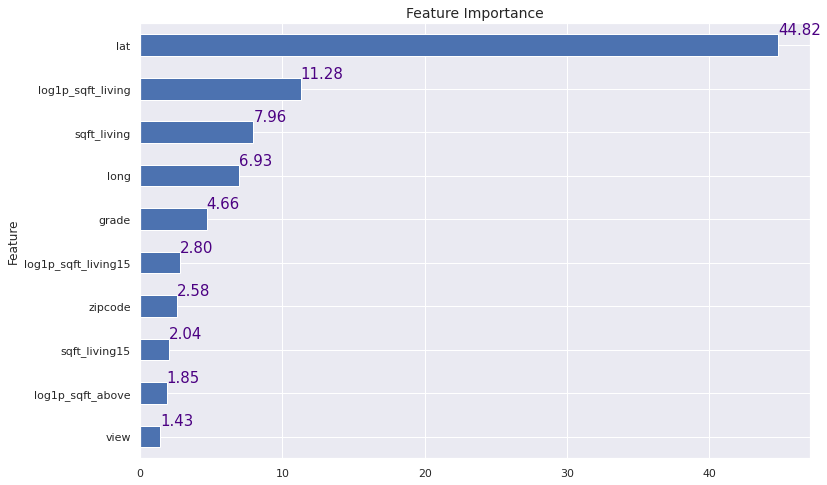

```python
plot_feature_imp_catboost(model,n=10)
```

# Metric Visualizer (only works in notebook, not jupyterlab or colab)

- [metric visualizer](https://catboost.ai/docs/concepts/python-reference_catboostipythonwidget.html)

```
import catboost
from catboost import CatBoostClassifier

# part 1: fit the model
cat_features = [0,1,2]

train_data = [["a", "b", 1, 4, 5, 6],
              ["a", "b", 4, 5, 6, 7],
              ["c", "d", 30, 40, 50, 60]]

train_labels = [1,1,0]

model = CatBoostClassifier(iterations=20,
                           loss_function = "CrossEntropy",
                           train_dir = "crossentropy")

model.fit(train_data, train_labels, cat_features)
predictions = model.predict(train_data)


# part 2: visualize
w = catboost.MetricVisualizer('/crossentropy/')
w.start()
```

Part 1 works in google colab and gives some files in the directory crossentroy but part2 keeps running for infinite time.

# Model Evaluation Using shap

- [official shap github repo](https://github.com/slundberg/shap)
- [catboost tutorials model analysis shap values tutorial](https://github.com/catboost/tutorials/blob/master/model_analysis/shap_values_tutorial.ipynb)
- [Kaggle: Machine Learning Interpretability](https://www.kaggle.com/datacog314/tutorial-machine-learning-interpretability/comments)

```python
import shap
```

```python
%%time

model = catboost.CatBoostRegressor(verbose=500,random_state=0)
model.fit(df_Xtrain_orig, ytrain_orig)

explainer = shap.TreeExplainer(model)
shap_values = explainer.shap_values(df_Xtest)
```

```
Learning rate set to 0.064823
0:	learn: 0.5023784	total: 10.4ms	remaining: 10.4s
500:	learn: 0.1408636	total: 4.53s	remaining: 4.51s
999:	learn: 0.1243705	total: 9.07s	remaining: 0us
CPU times: user 21.1 s, sys: 968 ms, total: 22 s
Wall time: 11.4 s
```

```python
df_Xtrain_orig.shape, df_Xtest.shape, shap_values.shape
```

```
((17290, 39), (4323, 39), (4323, 39))
```

```python
# load JS visualization code to notebook
shap.initjs()

# Look only first row of test data
# use matplotlib=True to avoid Javascript
shap.force_plot(explainer.expected_value,
                shap_values[0,:],
                df_Xtest.iloc[0,:],
                matplotlib=False,
                text_rotation=90)
```

```python
# the prediction for first row is 12.69 which is due to alll columns.
#
# red features contribute positive, blue features contribute negative.
# here, first row has sqft_living = 2,437, which is a good value it makes prediction higher
# but, lat = 47.35 makes the label prediction lower
```

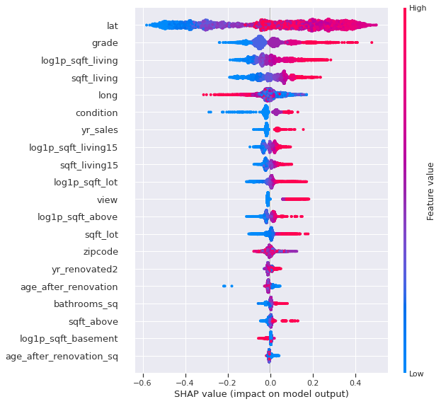

```python
shap.summary_plot(shap_values, df_Xtest)
```

This plot is made of many dots. Each dot has three characteristics:

- Vertical location shows what feature it is depicting
- Color shows whether that feature was high or low for that row of the dataset
- Horizontal location shows whether the effect of that value caused a higher or lower prediction.

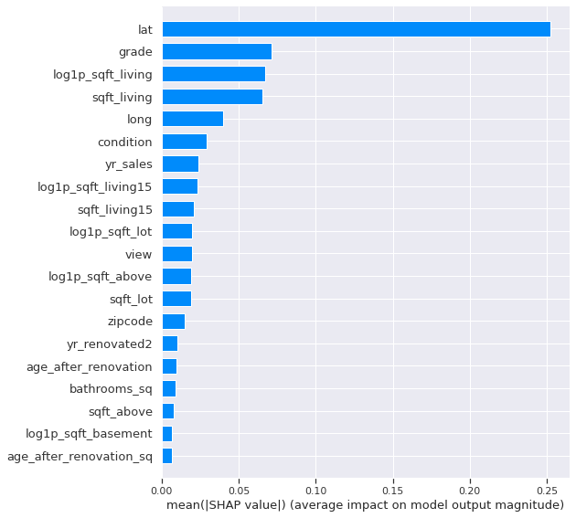

```python
shap.summary_plot(shap_values, df_Xtest, plot_type='bar')
```

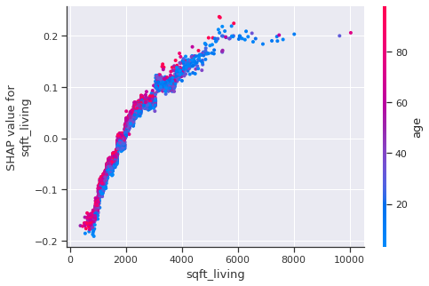

```python
shap.dependence_plot("sqft_living", shap_values, df_Xtest)
```

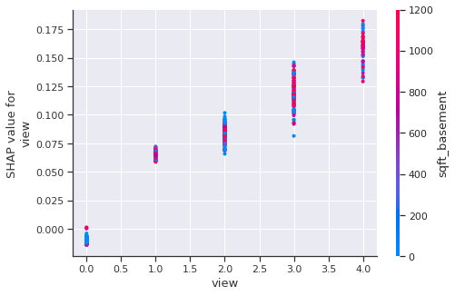

```python
shap.dependence_plot("view", shap_values, df_Xtest)
```

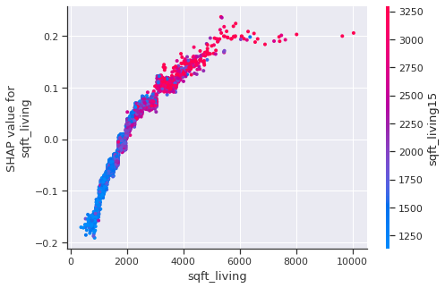

```python
shap.dependence_plot(ind='sqft_living', interaction_index='sqft_living15',
                     shap_values=shap_values,
                     features=df_Xtest,
                     display_features=df_Xtest)
```

# Time Taken

```python
time_taken = time.time() - time_start_notebook
h,m = divmod(time_taken,60*60)
print('Time taken to run whole notebook: {:.0f} hr '\
      '{:.0f} min {:.0f} secs'.format(h, *divmod(m,60)))
```

```
Time taken to run whole notebook: 0 hr 8 min 32 secs
```